# midterm

## **Introduction**

As we all know, breast cancer can occur in women but rarely in men. Until now, breast cancer becomes the second leading cause of cancer death in women. According to CDC (Center for Disease Control and Prevention)’s analysis, About 264,000 women and 2,400 men are given the diagnosis of breast cancer each year in the US. The United States loses 500 men and 42,000 women to breast cancer each year. Therefore, it is necessary for us to analyze the data of breast cancer patients and to discover the pathway and mechanism of breast cancer-related genes due to the high prevalence and mortality rate.

The Cancer Genome Atlas Program (TCGA) is a cancer genomics program that collects over 20,000 cancer tissue samples and matches them with normal samples spanning over 33 cancer types (National Institute of Health). The Clinical Proteomic Tumor Analysis Consortium (CPTAC) is a database that provides over 1100 patients’ proteogenomic data to analyze cancer (National Cancer Institute). These two publicly available databases are used for multi-omic data analysis, which integrates data sets from many omic groupings.

In this study, We explore the difference factors, such as race, gender, age, in breast cancer patients. And we will try to answer several questions:

What’s the difference between survival rate and race in women and try to analyze the reason behind this situation?

What’s the difference between survival rate and age category in women?

## **Method**

The analysis was mainly conducted in R using breast cancer clinical and RNAseq data. The data was sourced from TCGA with the TCGAbiolinks library using accession code “BRCA.” In the dataset, there were a total of 1174 patients. Of the patients that had sex listed in their clinical data, 1161 of the patients were female and only 13 were male.

```r
#if (!require("BiocManager", quietly = TRUE))
#    install.packages("BiocManager")
#BiocManager::install("TCGAbiolinks", force = TRUE)
library(TCGAbiolinks)
```

First, we select data only with female patients

```r
library(tidyverse)
clinic <- clinic %>%
          filter(gender == "FEMALE")
```

Then we try to deal with missing data for column race and age since these two columns we will use later. We find that after we extract the missing values, there are 108 patients do not have race information and all the patients have age information.

```r
# extract empty value in race
clinic_race_no_NAs <- clinic[!(clinic$race_list == "" | is.na(clinic$race_list)), ]
# extract empty value in age
clinic_age_no_NAs <- clinic[!(clinic$age_at_initial_pathologic_diagnosis == "" | is.na(clinic$age_at_initial_pathologic_diagnosis)), ]
```

Using the “age_at_initial_pathological_diagnosis” column in the clinical data, we compared patients with different age range. We use an ifelse() statement to add a new column called age_category, which stores the young vs. old classification. For the purposes of our analysis, we will define “young” as younger than 50 years old, and “old” as greater than or equal to 50 years old.

```r
# create the new column
clinic_age_no_NAs$age_category = ifelse(clinic_age_no_NAs$age_at_initial_pathologic_diagnosis <50, "young", "old")
```

## **Preliminary Results**

##### Question 1: What’s the difference between survival rate and race in women and try to analyze the reason behind this situation?

```r
library(survival)
library(survminer)
sum_exp_dataframe<- as.data.frame(clinic_race_no_NAs)

# replace the NA balue in days_to_death to days_to_last_follow_up
sum_exp_dataframe$days_to_death = ifelse(is.na(sum_exp_dataframe$days_to_death),
                                       sum_exp_dataframe$days_to_last_followup, sum_exp_dataframe$days_to_death)
```

```r
# make the days_to_death column numeric
sum_exp_dataframe$days_to_death = as.numeric(sum_exp_dataframe$days_to_death)
# create the death_event column here
sum_exp_dataframe$death_event = ifelse(sum_exp_dataframe$vital_status == "Alive", 0, 1)
```

```r
# We initialize a 'survival' object first, which contains the data we need.
surv_object <- Surv(time = sum_exp_dataframe$days_to_death,
                    event = sum_exp_dataframe$death_event)

# We then create a fit object to do the race analysis
race_fit <- surv_fit( surv_object ~ sum_exp_dataframe$race_list, data = sum_exp_dataframe )
```

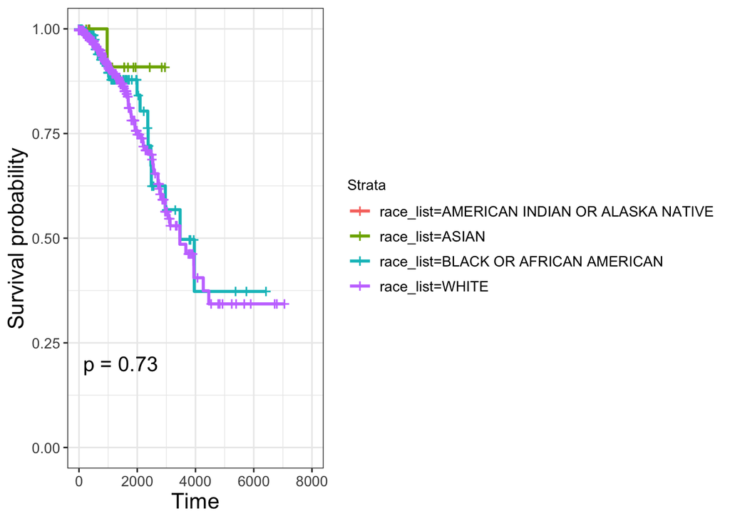

```r
#the ggtheme and legend arguments are for formatting.
# Feel free to play around with the margins and legend placement
survplot = ggsurvplot(race_fit,
                      pval=TRUE,
                      ggtheme = theme(plot.margin = unit(c(1,1,1,1), "cm")),
                      legend = "right")
# draw the final plot
p = survplot$plot +
  theme_bw() +  # changes the appearance to be a bit prettier
  theme(axis.title = element_text(size=15), # increase font sizes
        axis.text = element_text(size=10),
        legend.title = element_text(size=10),
        legend.text = element_text(size=10))
p
```

From the graph, we can see that the p value is 0.73 which is extremely large. In this case, we cannot conclude that a significant difference exists. However, there are many reasons in it. First of all, we only have 1053 sample size which is extremely small. Since human’s population is extremely large, there should be more sample size to show the significant results. In addition, it is due to the sample bias. In race list, there is only 1 patient from “AMERICAN INDIAN OR ALASKA NATIVE” category, and there are only 62 patients from “ASIAN” cateogory. The rest of patients are all WHITE or BLACK OR AFRICAN AMERICAN. Because of that, we closer look at these two races: WHITE, BLACK OR AFRICAN AMERICAN.

```r
sum_exp_dataframe_sub <- sum_exp_dataframe %>%
          filter(race_list == "WHITE" | race_list == "BLACK OR AFRICAN AMERICAN" )

surv_object <- Surv(time = sum_exp_dataframe_sub$days_to_death,
                    event = sum_exp_dataframe_sub$death_event)

race_sub_fit <- surv_fit( surv_object ~ sum_exp_dataframe_sub$race_list, data = sum_exp_dataframe_sub )
```

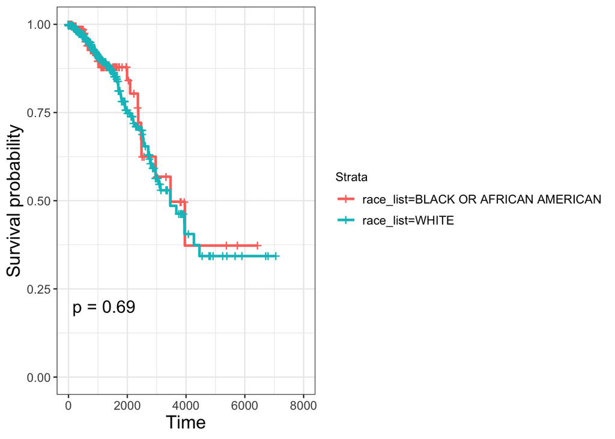

```r
survplot = ggsurvplot(race_sub_fit,
                      pval=TRUE,
                      ggtheme = theme(plot.margin = unit(c(1,1,1,1), "cm")),
                      legend = "right")
# draw the final plot
p = survplot$plot +
  theme_bw() +  # changes the appearance to be a bit prettier
  theme(axis.title = element_text(size=15), # increase font sizes
        axis.text = element_text(size=10),
        legend.title = element_text(size=10),
        legend.text = element_text(size=10))
p
```

We could see that the p-value decreases but still big enough to hard to draw the conclusion. However, according to the general conclusion from other research papers. The overall trend for survival rate is higher in white patients rather than in Black or American American patients due to the wealth index and region difference.

##### Question 2: What’s the difference between survival rate and age category in women?

```r
sum_exp_dataframe_age<- as.data.frame(clinic_age_no_NAs)

# replace the NA balue in days_to_death to days_to_last_follow_up
sum_exp_dataframe_age$days_to_death = ifelse(is.na(sum_exp_dataframe_age$days_to_death),
                                       sum_exp_dataframe_age$days_to_last_followup, sum_exp_dataframe_age$days_to_death)
```

```r
# make the days_to_death column numeric
sum_exp_dataframe_age$days_to_death = as.numeric(sum_exp_dataframe_age$days_to_death)
# create the death_event column here
sum_exp_dataframe_age$death_event = ifelse(sum_exp_dataframe_age$vital_status == "Alive", 0, 1)
```

```r
# We initialize a 'survival' object first, which contains the data we need.
surv_object <- Surv(time = sum_exp_dataframe_age$days_to_death,
                    event = sum_exp_dataframe_age$death_event)

# We then create a fit object to do the race analysis
age_fit <- surv_fit( surv_object ~ sum_exp_dataframe_age$age_category, data = sum_exp_dataframe_age )
```

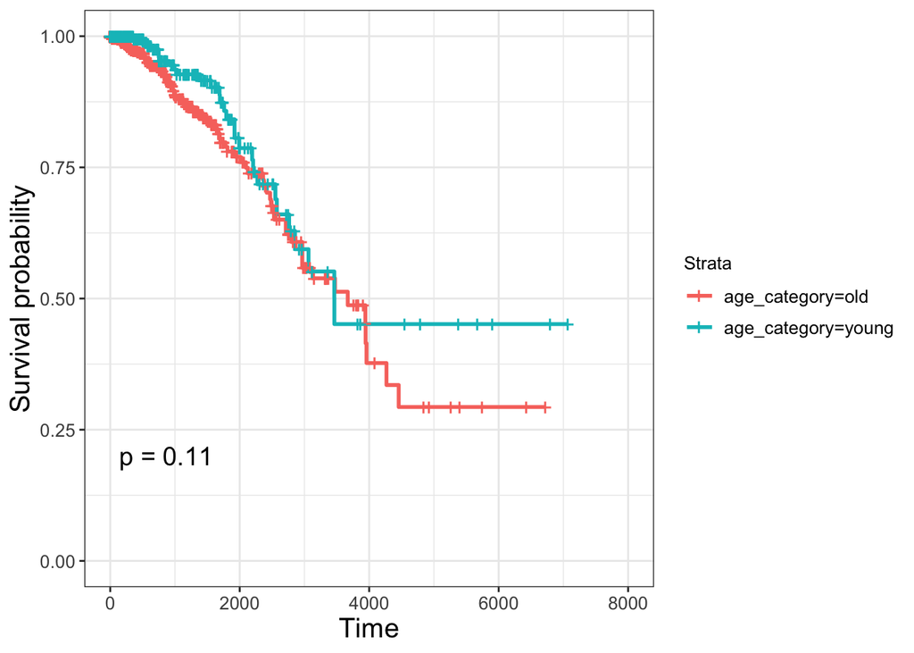

```r
#the ggtheme and legend arguments are for formatting.
# Feel free to play around with the margins and legend placement
survplot = ggsurvplot(age_fit,
                      pval=TRUE,
                      ggtheme = theme(plot.margin = unit(c(1,1,1,1), "cm")),
                      legend = "right")
# draw the final plot
p_age = survplot$plot +
  theme_bw() +  # changes the appearance to be a bit prettier
  theme(axis.title = element_text(size=15), # increase font sizes
        axis.text = element_text(size=10),
        legend.title = element_text(size=10),
        legend.text = element_text(size=10))
p_age
```

```r
library(devtools)
#slam_url <- "https://cran.r-project.org/src/contrib/Archive/slam/slam_0.1-37.tar.gz"
#install_url(slam_url)

#install_github("PoisonAlien/maftools", force = TRUE)
```

```r
library(maftools)

colnames(clinic)[colnames(clinic) == "bcr_patient_barcode"] <- "Tumor_Sample_Barcode"
```

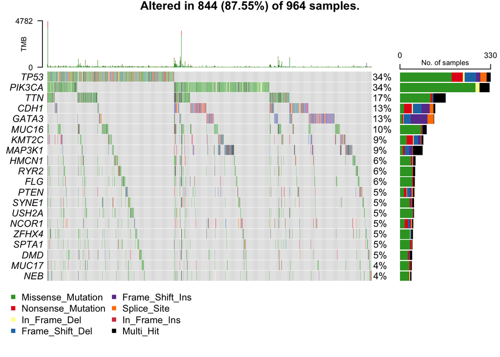

```r
oncoplot(maf = maf_object,
         top = 20)
```

From the graph, we can see that TP53 is the most mutated genes comparing with other genes.

```r
# downloading the query
#query <- GDCquery(project = "TCGA-BRCA",
#                  data.category = "Transcriptome Profiling",
#                  data.type = "Gene Expression Quantification",
#                  workflow.type = "STAR - Counts")

#sum_exp = GDCprepare(query)
```

```r
# Find the Ensembl gene ID of gene TP53
#TP53_ensembl_mask <- rowData(sum_exp)$gene_name == "TP53"
#ensembl_TP53 <- rowData(sum_exp)$gene_id[TP53_ensembl_mask]
```

```r
# find the NA values on gender
#bool_gender_na = is.na(colData(sum_exp)$gender)
# exclude the NA values in gender
#gender_cat_no_NAs = sum_exp$gender[!bool_gender_na]
# Count the genes with gender
#gene_counts = assays(sum_exp)$unstranded[ensembl_TP53,!bool_gender_na]
```

```r
#boxplot(gene_counts ~ gender_cat_no_NAs,
#        main = "TP53 counts on male vs. female",
#        xlab = "Gender",
#        ylab = "Gene Count",
#        cex.axis = 1,
#        col="orange")
```